# Subtype: T / NK

### 8. Annotation

最终亚型名字。后面组成和通路分析用这里的标签。

命名用的分辨率须与 cluster 对照图一致。先填标签，再看 cluster 7 的 QC，最后决定 7 要不要进 `drop_pre_annot`。14 / 15 确定丢掉。丢掉后按 B/plasma：Normalize → HVG → PCA → Harmony → UMAP（`dims = 1:20`），不再聚类。

```r
annot_cluster <- "harmony_clusters_1"
Idents(seurat_object) <- annot_cluster
```

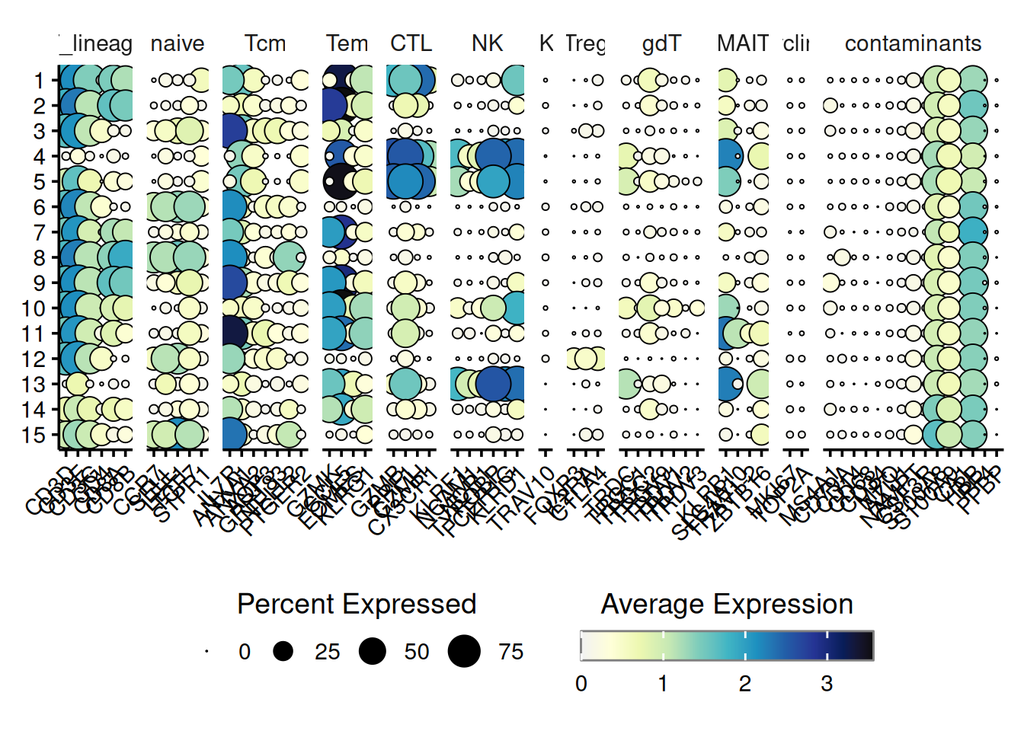

```r
Idents(seurat_object) <- annot_cluster
do_DotPlot(
  sample = seurat_object,
  flip = FALSE,
  legend.title = "Average Expression",
  legend.title.face = "plain",
  features = marker_groups,
  legend.length = 10
)
```

```r
ggsave(
  file.path(res_path, "05_markers_dotplot.pdf"),
  width = 16, height = 8, dpi = 600
)
```

```r
Idents(seurat_object) <- annot_cluster
table(Idents(seurat_object))
```

```
   1    2    3    4    5    6    7    8    9   10   11   12   13   14   15
1804 1741 1503 1492 1458 1450  944  778  543  465  396  316  255  126   86
```

```r
tnk_markers <- FindAllMarkers(seurat_object, only.pos = TRUE)
marker_table <-
  tnk_markers |>
  group_by(cluster) |>
  slice_head(n = 20) |>
  mutate(rank = paste0("Top_", row_number())) |>
  pivot_wider(id_cols = rank, names_from = cluster, values_from = gene)
marker_table
```

```
# A tibble: 20 × 16
   rank  `1`   `2`   `3`   `4`   `5`   `6`   `7`   `8`   `9`   `10`  `11`  `12`
   <chr> <chr> <chr> <chr> <chr> <chr> <chr> <chr> <chr> <chr> <chr> <chr> <chr>
 1 Top_1 GZMH  GZMK  LTB   FCER… FCGR… LEF1  GZMK  NELL2 IFNG… SPRY2 SLC4… RTKN2
 2 Top_2 FGFB… HLA-… IL7R  TYRO… GZMB  LTB   RPL41 LEF1  IL7R  IKZF2 RORC  FOXP3
 3 Top_3 GZMB  HLA-… CD40… KLRF1 GNLY  CCR7  RPS27 CCR7  GZMK  TRDV3 ME1   RBMS3
 4 Top_4 ZNF6… CD74  ADAM… FCGR… KLRC2 MAL   RPL39 BACH2 MS4A1 ITGAD IL23R IL2RA
 5 Top_5 NKG7  CCL5  CD4   CLIC3 FGFB… TSHZ2 RPS28 LINC… CD8A  GCSAM LTK   ENSG…
 6 Top_6 CD52  CD8A  CCR6  GZMB  GZMH  ANKR… RPS12 ACTN1 CD8B  TRDV1 ADAM… CTLA4
 7 Top_7 ZEB2  HLA-… PTPN… FGFB… KLRD1 RPL22 RPS1… AIF1  FXYD2 CMC1  LINC… F5
 8 Top_8 ENSG… CD8B  ANK3  SPON2 KLRC3 RPS5  RPS2… CD248 PARP8 ENSG… ENSG… DNAH8
 9 Top_9 ITGB1 CXCR6 GPR1… GNLY  TYRO… RPL5  RPL30 PTPRK NELL2 XCL1  P2RY… IKZF2
10 Top_… SH3B… RGS1  AQP3  KLRD1 KLRF1 RPL9  RPL28 LRRN3 CAMK4 XCL2  CCR6  CDK14
11 Top_… PRSS… HLA-… VIM   SH2D… ZEB2  RPS10 RPL32 CD8B  CASK  DRAIC IL7R  RBMS…
12 Top_… GNLY  GZMA  INPP… CEBPD CX3C… RPL29 RPS3  RPS13 PCAT1 ENSG… DPP4  FANK1
13 Top_… EFHD2 CCL4  TIMP1 KLRB1 PRF1  RPL18 RPL13 CD79A CXCR3 CD160 CEBPD ICA1
14 Top_… S100… HLA-… S100… CX3C… C1or… RPL1… IL32  RPL32 THEM… AOAH  TRBV… ENSG…
15 Top_… CX3C… IL32  TNFR… PTPN… PRSS… RPL3… RPS25 RPS12 LSR   CD74  TRAV… NEBL
16 Top_… CD8A  TOX   ENSG… IGFB… GPR1… RPS6  RPL34 TRAB… DUSP2 GZMK  PRSS… ENSG…
17 Top_… C1or… CCL4… SERI… MCTP2 ADGR… RPS25 RPS18 ENSG… MT-N… CCL5  KIF5C TBC1…
18 Top_… HLA-C HLA-… TPT1  PRF1  ENSG… RPS13 RPS15 RPS8  CRYB… HLA-… B3GA… HACD1
19 Top_… HLA-… CRTAM LINC… TTC38 TRDC  RPS23 RPS23 NT5E  NR3C2 CRTAM RUNX2 PLCL1
20 Top_… LINC… HLA-… ADAM… GPR1… ENSG… RPS14 B2M   RPS23 BTG1  EOMES KLRB1 LINC…
# ℹ 3 more variables: `13` <chr>, `14` <chr>, `15` <chr>
```

`cluster_map` 的 key 必须对应 `annot_cluster`。

```r
cluster_map <- c(
  "1" = "CD8 CTL",
  "2" = "CD8 Tem",
  "3" = "CD4 Tcm",
  "4" = "CD56dim NK",
  "5" = "CD8 NKT",
  "6" = "CD4 Tnaive",
  "7" = "Ribo",
  "8" = "CD8 Tnaive",
  "9" = "CD8 Tem",
  "10" = "gdT",
  "11" = "MAIT",
  "12" = "CD4 Treg",
  "13" = "CD56bright NK"
)
```

```r
ribo_cluster <- "7"
cluster_ids <- as.character(FetchData(seurat_object, vars = annot_cluster)[, 1])
is_ribo <- cluster_ids == ribo_cluster
message(sprintf("Cluster %s: %s cells.", ribo_cluster, sum(is_ribo)))

qc_vars <- c(
  annot_cluster, "nFeature_RNA", "nCount_RNA", "percent_mt",
  "is_doublet", "sample"
)
if ("doublet_score" %in% colnames(seurat_object[[]])) {
  qc_vars <- c(qc_vars, "doublet_score")
}
ribo_qc <- FetchData(seurat_object, vars = qc_vars)[is_ribo, ]

print(summary(ribo_qc$nFeature_RNA))
```

```
   Min. 1st Qu.  Median    Mean 3rd Qu.    Max.
  303.0   622.2   860.0   949.0  1178.5  2871.0
```

```r
print(summary(ribo_qc$nCount_RNA))
```

```
   Min. 1st Qu.  Median    Mean 3rd Qu.    Max.
    501    1059    1634    2028    2605   12716
```

```r
print(summary(ribo_qc$percent_mt))
```

```
   Min. 1st Qu.  Median    Mean 3rd Qu.    Max.
 0.0000  0.8667  1.4867  1.6509  2.2590  4.8458
```

```r
print(table(ribo_qc$is_doublet, useNA = "ifany"))
```

```
singlet doublet
    938       6
```

```r
print(table(ribo_qc$sample, useNA = "ifany"))
```

```
 ACI-1  ACI-2  ACI-3  ACI-4  ACI-5 CTRL-1 CTRL-2 CTRL-3 CTRL-4 CTRL-5 CTRL-6
    30     25     44     15     17    103    330    103    201     14     62
```

```r
print(round(prop.table(table(ribo_qc$sample)), 3))
```

```
 ACI-1  ACI-2  ACI-3  ACI-4  ACI-5 CTRL-1 CTRL-2 CTRL-3 CTRL-4 CTRL-5 CTRL-6
 0.032  0.026  0.047  0.016  0.018  0.109  0.350  0.109  0.213  0.015  0.066
```

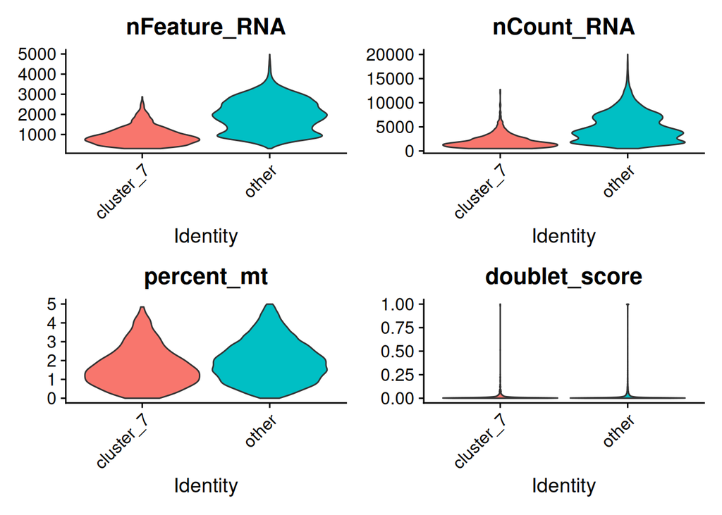

```r
seurat_object$ribo_check <- ifelse(is_ribo, paste0("cluster_", ribo_cluster), "other")
VlnPlot(
  seurat_object,
  features = intersect(
    c("nFeature_RNA", "nCount_RNA", "percent_mt", "doublet_score"),
    colnames(seurat_object[[]])
  ),
  group.by = "ribo_check",
  pt.size = 0, ncol = 2
)
```

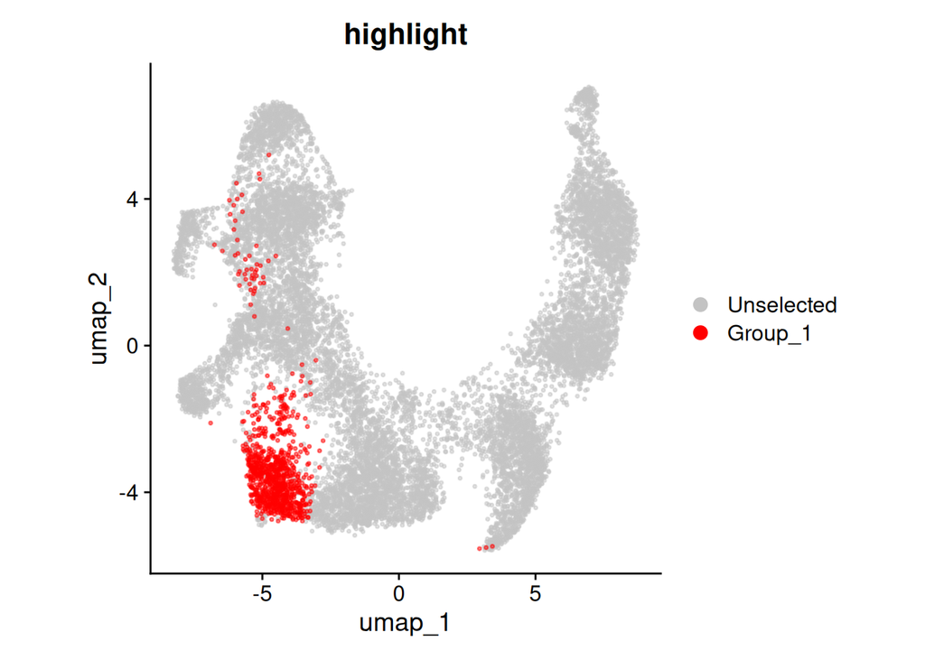

```r
ggsave(file.path(res_path, "05_markers_ribo_qc.pdf"), width = 10, height = 8)

DimPlot(
  seurat_object, reduction = "umap", group.by = "sample",
  cells.highlight = colnames(seurat_object)[is_ribo],
  cols.highlight = "red", sizes.highlight = pt_size,
  pt.size = pt_size, alpha = alpha, raster = raster, raster.dpi = raster_dpi
) + theme(aspect.ratio = 1)
```

```r
ggsave(file.path(res_path, "05_markers_ribo_umap.pdf"), width = 8, height = 8)
```

```r
# 14 / 15 确定删。看完上面 cluster 7 的 QC 后，若要删 7，改成 c("14", "15", "7")
drop_pre_annot <- c("7", "14", "15")
n_before <- ncol(seurat_object)
keep_cells <- colnames(seurat_object)[
  !(as.character(FetchData(seurat_object, vars = annot_cluster)[, 1]) %in%
    as.character(drop_pre_annot))
]
seurat_object <- subset(seurat_object, cells = keep_cells)
message(sprintf(
  "Dropped clusters %s: %s cells; %s remain.",
  paste(drop_pre_annot, collapse = ", "),
  n_before - ncol(seurat_object),
  ncol(seurat_object)
))
```

```r
if (length(cluster_map) == 0) {
  message("cluster_map empty; skip subtype annotation.")
} else {
  cluster_ids <- as.character(
    FetchData(seurat_object, vars = annot_cluster)[, 1]
  )
  seurat_object$annot_subtype <- unname(cluster_map[cluster_ids])
  annot_levels <- c(
    "CD4 Tnaive", "CD4 Tcm", "CD4 Treg",
    "CD8 Tnaive", "CD8 Tem", "CD8 CTL", "CD8 NKT",
    "MAIT", "gdT", "CD56bright NK", "CD56dim NK"
  )
  seurat_object$annot_subtype <- factor(
    seurat_object$annot_subtype,
    levels = intersect(annot_levels, unique(seurat_object$annot_subtype))
  )
  table(seurat_object$annot_subtype, useNA = "ifany")
}
```

```
   CD4 Tnaive       CD4 Tcm      CD4 Treg    CD8 Tnaive       CD8 Tem
         1450          1503           316           778          2284
      CD8 CTL       CD8 NKT          MAIT           gdT CD56bright NK
         1804          1458           396           465           255
   CD56dim NK
         1492
```

标注已经定在 `annot_subtype` 上。丢掉细胞后再 Normalize → HVG → PCA → Harmony → UMAP（`dims = 1:20`，reduction 名 `umap`），**不再聚类**。PCA 仍排除 TR。

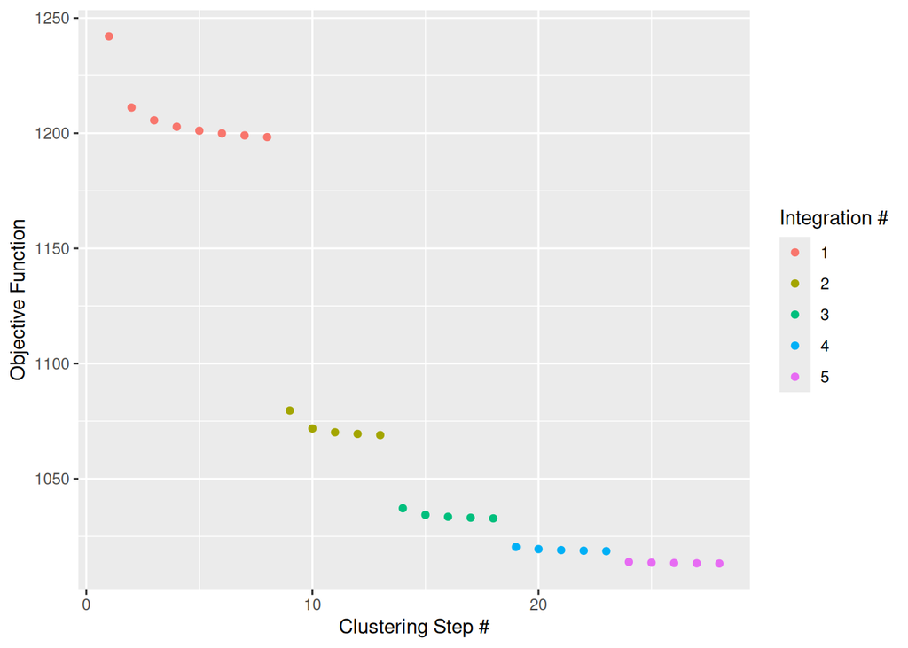

```r
Idents(seurat_object) <- "sample"
seurat_object[["RNA"]]$data <- NULL
seurat_object[["RNA"]]$scale.data <- NULL
seurat_object <- NormalizeData(seurat_object, verbose = TRUE)
seurat_object <- FindVariableFeatures(
  seurat_object, nfeatures = n_hvg, verbose = TRUE
)
pca_features <- setdiff(
  VariableFeatures(seurat_object),
  test_genes$gene[test_genes$unwant | test_genes$tr]
)
seurat_object <- ScaleData(seurat_object, features = pca_features, assay = "RNA")
seurat_object <- RunPCA(
  seurat_object, npcs = 50, features = pca_features,
  verbose = TRUE, reduction.name = "pca"
)
tic("Harmony integration")
seurat_object <- RunHarmony(
  seurat_object, c("sample"), ncores = 15, plot_convergence = TRUE
)
```

```r
toc()
```

```
Harmony integration: 5.558 sec elapsed
```

```r
seurat_object <- RunUMAP(
  seurat_object, dims = 1:20, reduction = "harmony",
  reduction.name = "umap"
)
```

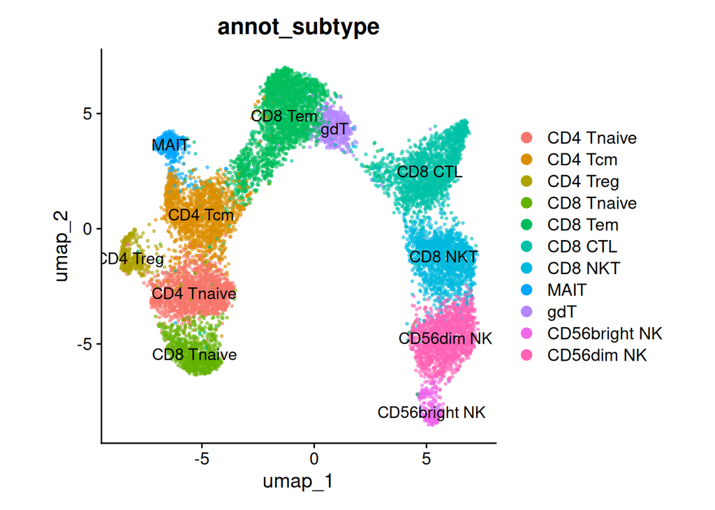

```r
DimPlot(
  seurat_object,
  reduction = "umap",
  group.by = "annot_subtype",
  pt.size = pt_size,
  alpha = alpha,
  raster = raster,
  raster.dpi = raster_dpi,
  label = TRUE
) + theme(aspect.ratio = 1)
```

```r
ggsave(
  file.path(res_path, "06_annot_umap.pdf"),
  width = 8, height = 8, dpi = 600
)
```

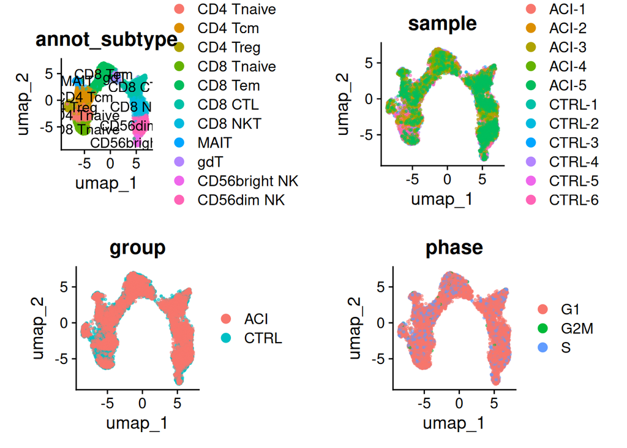

```r
plot_grid(
  ncol = 2,
  DimPlot(
    seurat_object, reduction = "umap", group.by = "annot_subtype",
    label = TRUE,
    pt.size = pt_size, alpha = alpha, raster = raster, raster.dpi = raster_dpi
  ) + theme(aspect.ratio = 1),
  DimPlot(
    seurat_object, reduction = "umap", group.by = "sample",
    pt.size = pt_size, alpha = alpha, raster = raster, raster.dpi = raster_dpi
  ) + theme(aspect.ratio = 1),
  DimPlot(
    seurat_object, reduction = "umap", group.by = "group",
    pt.size = pt_size, alpha = alpha, raster = raster, raster.dpi = raster_dpi
  ) + theme(aspect.ratio = 1),
  DimPlot(
    seurat_object, reduction = "umap", group.by = "phase",
    pt.size = pt_size, alpha = alpha, raster = raster, raster.dpi = raster_dpi
  ) + theme(aspect.ratio = 1)
)
```

```r
ggsave(
  file.path(res_path, "06_annot_overview.pdf"),
  width = 14, height = 12, dpi = 600
)
```

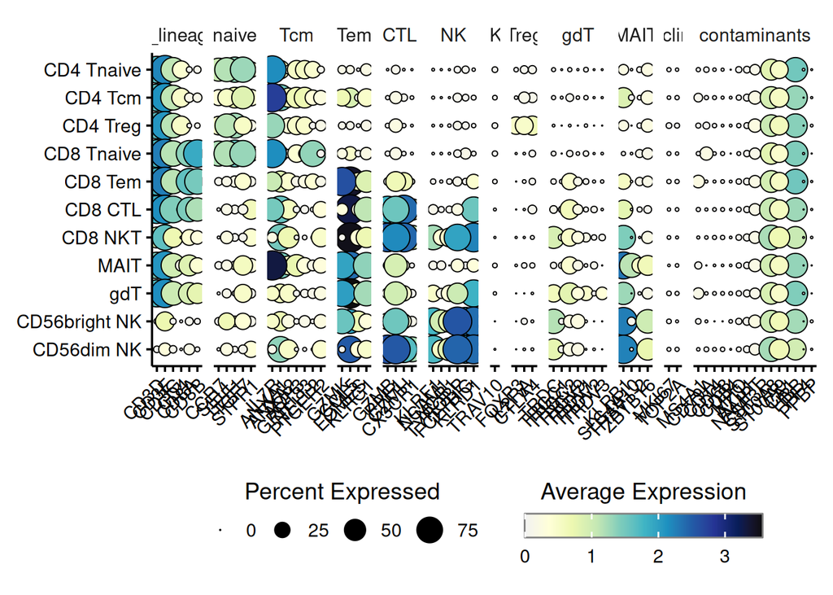

```r
Idents(seurat_object) <- "annot_subtype"
do_DotPlot(
  sample = seurat_object,
  flip = FALSE,
  legend.title = "Average Expression",
  legend.title.face = "plain",
  features = marker_groups,
  legend.length = 10
)
```

```r
ggsave(
  file.path(res_path, "06_annot_dotplot.pdf"),
  width = 16, height = 8, dpi = 600
)
```

```r
qs_save(
  seurat_object,
  file = file.path(obj_path, "seurat_object_tnk.qs2"),
  nthreads = 10
)
```